# 여러 육상 기록에 공통된 구조는 무엇인가

# 1 분석 질문

여자 육상 7종목 국가기록에 공통된 변동 축이 있는가? 총분산을 요약하는 PCA와 공통분산을 모형화하는 FA는 어떤 공통점과 차이를 보이는가?

# 2 데이터와 표준화

자료는 2005년 기준 54개 국가의 100m, 200m, 400m, 800m, 1500m, 3000m, 마라톤 기록이다. 재배포 허가가 분명하지 않아 원자료는 포함하지 않는다.

```r
data_path <- "../../data/raw/trackrecord2005-women.txt"
if (!file.exists(data_path)) {
  stop("육상 원자료가 없습니다. data/README.md의 획득·배치 안내를 확인하세요.")
}

records <- read.table(data_path, header = TRUE, check.names = FALSE)
colnames(records) <- c("100m", "200m", "400m", "800m",
                       "1500m", "3000m", "Marathon")
X <- as.matrix(records)
stopifnot(nrow(X) == 54, ncol(X) == 7)
knitr::kable(head(records), digits = 2,
             caption = "자료 구조 예시")
```

자료 구조 예시

|  | 100m | 200m | 400m | 800m | 1500m | 3000m | Marathon |
| --- | --- | --- | --- | --- | --- | --- | --- |
| ARG | 11.57 | 22.94 | 52.50 | 2.05 | 4.25 | 9.19 | 150.32 |
| AUS | 11.12 | 22.23 | 48.63 | 1.98 | 4.02 | 8.63 | 143.51 |
| AUT | 11.15 | 22.70 | 50.62 | 1.94 | 4.05 | 8.78 | 154.35 |
| BEL | 11.14 | 22.48 | 51.45 | 1.97 | 4.08 | 8.82 | 143.05 |
| BER | 11.46 | 23.05 | 53.30 | 2.07 | 4.29 | 9.81 | 174.18 |
| BRA | 11.17 | 22.60 | 50.62 | 1.97 | 4.17 | 9.04 | 147.41 |

단거리 기록은 초, 중·장거리 기록은 분 단위여서 공분산행렬은 큰 단위를 가진 변수가 지배할 수 있다. 모든 분석은 표준화 자료, 즉 상관행렬을 기준으로 수행한다.

# 3 PCA

```r
R <- cor(X)
eig <- eigen(R)
variance <- eig$values / sum(eig$values)

pca_variance <- data.frame(
  component = paste0("PC", seq_along(variance)),
  explained_percent = 100 * variance,
  cumulative_percent = 100 * cumsum(variance)
)
knitr::kable(pca_variance, digits = 2,
             caption = "PCA 설명력")
```

PCA 설명력

| component | explained_percent | cumulative_percent |
| --- | --- | --- |
| PC1 | 82.97 | 82.97 |
| PC2 | 8.98 | 91.95 |
| PC3 | 3.99 | 95.94 |
| PC4 | 1.78 | 97.72 |
| PC5 | 1.30 | 99.02 |
| PC6 | 0.78 | 99.80 |
| PC7 | 0.20 | 100.00 |

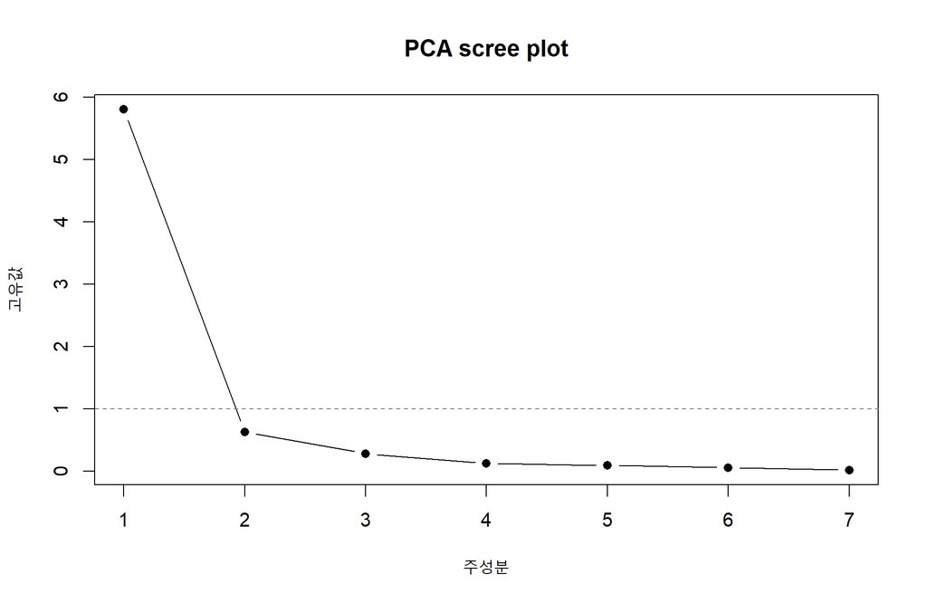

```r
plot(eig$values, type = "b", pch = 16,
     xlab = "주성분", ylab = "고유값", main = "PCA scree plot")
abline(h = 1, lty = 2, col = "grey50")
```

PC1은 82.97%, PC2까지는 91.95%의 총분산을 설명한다. 두 번째 고유값은 1보다 작고 첫 축이 압도적이지만, scree plot의 꺾임과 종목군 대비를 시각화하려는 목적에서 두 축을 살펴본다.

```r
# 변수와 주성분 점수의 상관: eigenvector × sqrt(eigenvalue)
pca_loadings <- eig$vectors[, 1:2, drop = FALSE] %*%
  diag(sqrt(eig$values[1:2]))
rownames(pca_loadings) <- colnames(X)
colnames(pca_loadings) <- c("PC1", "PC2")
knitr::kable(pca_loadings, digits = 3,
             caption = "변수–주성분 상관")
```

변수–주성분 상관

|  | PC1 | PC2 |
| --- | --- | --- |
| 100m | -0.910 | -0.323 |
| 200m | -0.923 | -0.328 |
| 400m | -0.887 | -0.364 |
| 800m | -0.951 | 0.128 |
| 1500m | -0.938 | 0.245 |
| 3000m | -0.906 | 0.336 |
| Marathon | -0.856 | 0.309 |

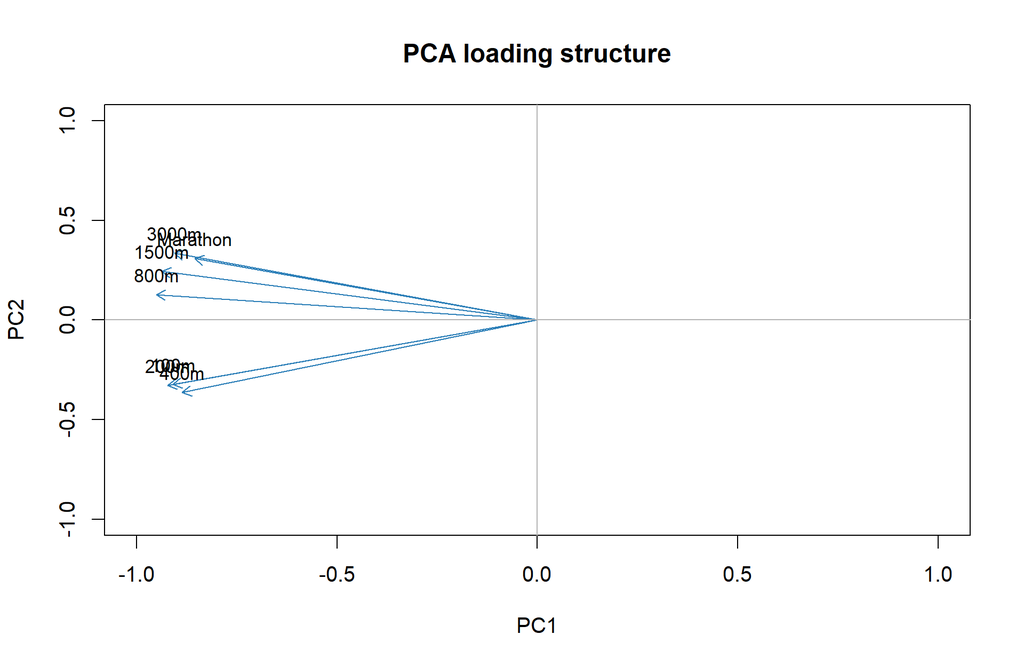

```r
plot(pca_loadings, type = "n", xlim = c(-1, 1), ylim = c(-1, 1),
     xlab = "PC1", ylab = "PC2", main = "PCA loading structure")
arrows(0, 0, pca_loadings[, 1], pca_loadings[, 2],
       length = 0.08, col = "#2C7FB8")
text(pca_loadings, labels = rownames(pca_loadings), pos = 3, cex = 0.85)
abline(h = 0, v = 0, col = "grey70")
```

PC1은 모든 종목에 절대값 0.86 이상으로 크게 적재되어 기록 전반의 공통 변동을 요약한다. PC2는 100~400m와 800m 이상에서 부호가 갈려 단거리와 중·장거리 기록의 상대적 대비를 나타낸다. 주성분의 부호는 뒤집어도 같은 해이므로 방향보다 상대적 패턴이 중요하다.

# 4 Factor Analysis

## 4.1 Principal-component factor analysis

```r
pcfa_loadings <- eig$vectors[, 1:2, drop = FALSE] %*%
  diag(sqrt(eig$values[1:2]))
rownames(pcfa_loadings) <- colnames(X)
colnames(pcfa_loadings) <- c("PCFA1", "PCFA2")

pcfa_contribution <- 100 * colSums(pcfa_loadings^2) / ncol(X)
knitr::kable(pcfa_loadings, digits = 3,
             caption = "PCFA 적재량(비회전)")
```

PCFA 적재량(비회전)

|  | PCFA1 | PCFA2 |
| --- | --- | --- |
| 100m | -0.910 | -0.323 |
| 200m | -0.923 | -0.328 |
| 400m | -0.887 | -0.364 |
| 800m | -0.951 | 0.128 |
| 1500m | -0.938 | 0.245 |
| 3000m | -0.906 | 0.336 |
| Marathon | -0.856 | 0.309 |

PCFA는 PCA의 첫 두 축과 같은 계산 구조를 사용하므로 첫 공통 축과 단거리–중장거리 대비를 그대로 보인다. 두 요인의 총기여율은 91.95%다.

## 4.2 Maximum-likelihood factor analysis

```r
Z <- scale(X)
mlfa <- factanal(Z, factors = 2, rotation = "none", scores = "regression")
mlfa_loadings <- unclass(mlfa$loadings)
mlfa_contribution <- 100 * colSums(mlfa_loadings^2) / ncol(X)

knitr::kable(mlfa_loadings, digits = 3,
             caption = "MLFA 적재량(비회전)")
```

MLFA 적재량(비회전)

|  | Factor1 | Factor2 |
| --- | --- | --- |
| 100m | 0.876 | 0.372 |
| 200m | 0.898 | 0.411 |
| 400m | 0.826 | 0.406 |
| 800m | 0.925 | -0.005 |
| 1500m | 0.974 | -0.186 |
| 3000m | 0.945 | -0.281 |
| Marathon | 0.809 | -0.090 |

```r
fit_table <- data.frame(
  statistic = unname(mlfa$STATISTIC),
  df = mlfa$dof,
  p_value = unname(mlfa$PVAL),
  two_factor_loading_ss_percent = sum(mlfa_contribution)
)
knitr::kable(fit_table, digits = 4,
             caption = "MLFA 적합도와 적재 제곱합 비율")
```

MLFA 적합도와 적재 제곱합 비율

| statistic | df | p_value | two_factor_loading_ss_percent |
| --- | --- | --- | --- |
| 31.4311 | 8 | 1e-04 | 88.6164 |

MLFA의 첫 요인도 모든 종목에 크게 적재된다. 두 번째 요인은 단거리와 장거리의 대비를 일부 보이지만, 800m와 마라톤 적재는 0에 가깝고 PCFA보다 패턴이 약하다. 2요인 MLFA의 적재 제곱합은 변수 총수 대비 88.62%다. 적합도 검정의 작은 p-value는 2요인 모형이 상관구조를 완전히 설명하지 못한다는 경고이므로 결과를 확정적 잠재구조로 보지 않는다.

# 5 PCA와 FA 비교

```r
comparison <- data.frame(
  method = c("PCA", "PCFA", "MLFA"),
  target = c("총분산 요약", "주성분 기반 공통성 요약", "공통요인 모형"),
  first_axis_percent = c(100 * variance[1], pcfa_contribution[1], mlfa_contribution[1]),
  first_two_percent = c(100 * sum(variance[1:2]),
                        sum(pcfa_contribution), sum(mlfa_contribution))
)
knitr::kable(comparison, digits = 2,
             caption = "방법별 목적과 두 축의 요약")
```

방법별 목적과 두 축의 요약

|  | method | target | first_axis_percent | first_two_percent |
| --- | --- | --- | --- | --- |
|  | PCA | 총분산 요약 | 82.97 | 91.95 |
| PCFA1 | PCFA | 주성분 기반 공통성 요약 | 82.97 | 91.95 |
| Factor1 | MLFA | 공통요인 모형 | 80.13 | 88.62 |

세 방법 모두 강한 첫 공통 축을 보이며, 두 번째 축에서 단거리와 중·장거리의 상대적 차이가 나타난다는 점은 같다. 그러나 PCA의 설명력은 총분산 비율이고, FA의 적재 제곱합은 공통분산 모형의 요약이므로 같은 지표처럼 직접 비교해서는 안 된다.

# 6 한계

- 두 차원 선택은 scree plot과 누적 설명력에 주로 의존한다. parallel analysis나 별도 표본 검증이 없어 요인 수 선택 근거가 제한적이다.
- 국가기록은 선수 개인의 능력이나 국가 정책의 인과효과를 뜻하지 않는다.
- 2005년의 국가별 최고기록이라는 표본 구성과 측정 맥락에 결과가 의존한다.
- 비회전 해는 원본 분석과의 비교를 위한 선택이다. 다른 회전은 두 번째 요인의 해석을 바꿀 수 있다.